# Project 2: Data Mining, Classification, Prediction

SDS322E

# Mining, Classification, Prediction

Krystal Li KML3695

### Introduction

I chose this data solely because I am a Starbucks fan - I found this data on the Vincentarelbundock website, and chose to go with it because I thought it would be interesting to analyze the different foods at Starbucks. The variables measured are as follows: item, calories, fat, carb, fiber, protein, and type. I made a separate categorical column called highcals, that denotes whether the item is high in calories or not, based on if it was higher than the mean of the calories. There are 77 observations, 48 of which are high calories and 29 of which are not. I also created a column called highcals2, which codes whether the food items are high calories or not with 1 and 2, so that it can be used for a confusion matrix later on.

```r
library(tidyverse)
starbucks <- read_csv("~/project2/starbucks.csv")
starbucks <- starbucks %>% mutate(highcals = ifelse(calories >
    mean(calories), "TRUE", "FALSE"))
highcals2 <- as.integer(as.factor(starbucks$highcals))
starbucks <- starbucks %>% mutate(highcals2)
starbucks %>% select(highcals) %>% filter(highcals2 == "2") %>%
    summarize(n = n())
```

```
## # A tibble: 1 x 1
##       n
##   <int>
## 1    48
```

```r
starbucks %>% select(highcals) %>% filter(highcals2 == "1") %>%
    summarize(n = n())
```

```
## # A tibble: 1 x 1
##       n
##   <int>
## 1    29
```

```r
starbucks <- starbucks %>% select(item:highcals2)
head(starbucks)
```

```
## # A tibble: 6 x 9
##   item               calories   fat  carb fiber protein type  highcals highcals2
##   <chr>                 <dbl> <dbl> <dbl> <dbl>   <dbl> <chr> <chr>        <int>
## 1 8-Grain Roll            350     8    67     5      10 bake… TRUE             2
## 2 Apple Bran Muffin       350     9    64     7       6 bake… TRUE             2
## 3 Apple Fritter           420    20    59     0       5 bake… TRUE             2
## 4 Banana Nut Loaf         490    19    75     4       7 bake… TRUE             2
## 5 Birthday Cake Min…      130     6    17     0       0 bake… FALSE            1
## 6 Blueberry Oat Bar       370    14    47     5       6 bake… TRUE             2
```

### Cluster Analysis

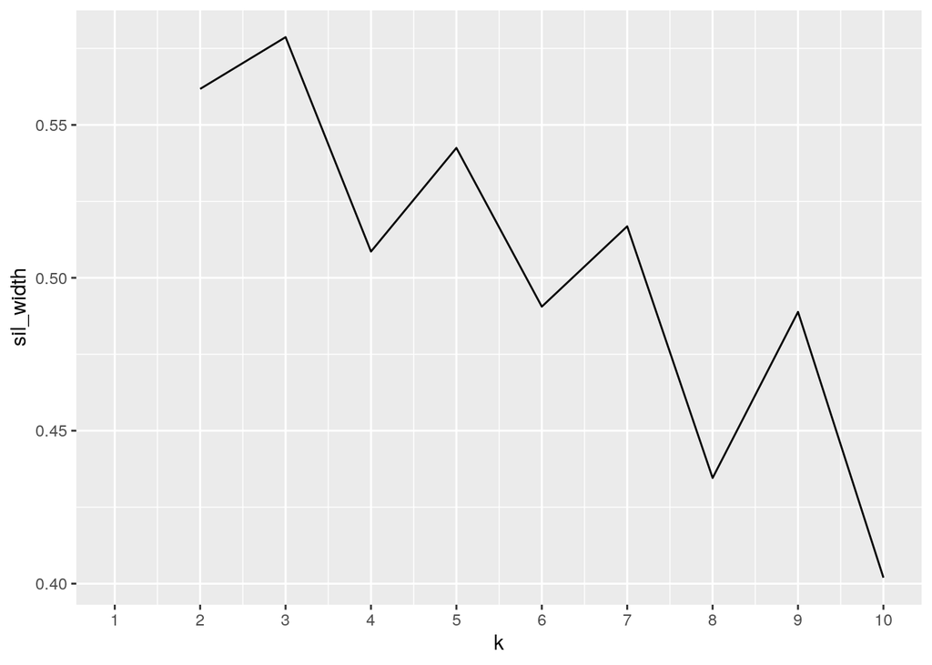

```r
library(cluster)

sil_width <- vector()
clust_dat <- starbucks %>% select(calories, fat, carb, fiber,
    protein)
for (i in 2:10) {
    kms <- kmeans(clust_dat, centers = i)
    sil <- silhouette(kms$cluster, dist(clust_dat))
    sil_width[i] <- mean(sil[, 3])
}
ggplot() + geom_line(aes(x = 1:10, y = sil_width)) + scale_x_continuous(name = "k",
    breaks = 1:10)
```

```r
starbucks_pam <- clust_dat %>% pam(k = 3)
starbucks_pam
```

```
## Medoids:
##      ID calories fat carb fiber protein
## [1,] 72      350  12   48     4      13
## [2,] 24      440  18   59     3       8
## [3,] 58      170   9   22     0       0
## Clustering vector:
##  [1] 1 1 2 2 3 1 2 1 1 2 1 1 1 2 1 2 2 2 3 1 1 2 2 2 1 3 1 1 2 1 3 1 1 2 2 2 2 1
## [39] 1 2 2 2 1 1 1 1 2 1 1 3 3 3 3 3 3 3 3 3 1 1 1 2 1 3 1 1 3 2 2 1 1 1 2 1 1 1
## [77] 1
## Objective function:
##    build     swap
## 32.64587 32.64587
##
## Available components:
##  [1] "medoids"    "id.med"     "clustering" "objective"  "isolation"
##  [6] "clusinfo"   "silinfo"    "diss"       "call"       "data"
```

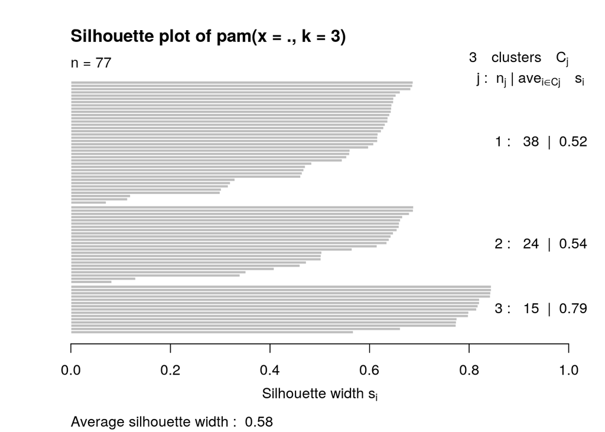

```r
plot(starbucks_pam, which = 2)
```

```r
starbucks %>% slice(starbucks_pam$id.med)
```

```
## # A tibble: 3 x 9
##   item              calories   fat  carb fiber protein type   highcals highcals2
##   <chr>                <dbl> <dbl> <dbl> <dbl>   <dbl> <chr>  <chr>        <int>
## 1 Roasted Vegetabl…      350    12    48     4      13 sandw… TRUE             2
## 2 Maple Oat Pecan …      440    18    59     3       8 bakery TRUE             2
## 3 Tiramisu Cake Pop      170     9    22     0       0 petite FALSE            1
```

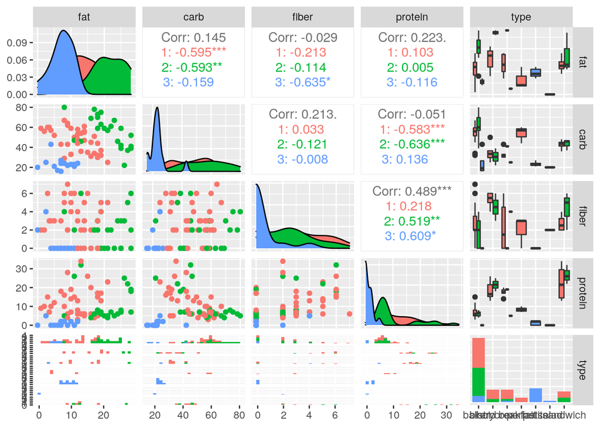

```r
library(GGally)
starbucks %>% mutate(cluster = as.factor(starbucks_pam$clustering)) %>%
    ggpairs(columns = 3:7, aes(color = cluster))
```

The purpose of clustering is to be able to group our data by patterns, and then to group them by those patterns. We can see then what features appear together, and what characterizes a group within the data frame. The 3 medoids that we see in the final slice are Roasted Vegetable Panini, Maple Oat Pecan Scone, and the Tiramisu Cake Pop, which means that those 3 food items are most representative of the final groups that we clustered.

### Dimensionality Reduction with PCA

```r
starbucks_num <- starbucks %>% select(calories:protein)
starbucks_pca <- princomp(starbucks_num, cor = T)
starbucks_pca
```

```
## Call:
## princomp(x = starbucks_num, cor = T)
##
## Standard deviations:
##     Comp.1     Comp.2     Comp.3     Comp.4     Comp.5
## 1.53039905 1.13003745 0.99773963 0.61660307 0.07218305
##
##  5  variables and  77 observations.
```

```r
summary(starbucks_pca, loadings = T)
```

```
## Importance of components:
##                           Comp.1    Comp.2    Comp.3     Comp.4      Comp.5
## Standard deviation     1.5303991 1.1300374 0.9977396 0.61660307 0.072183055
## Proportion of Variance 0.4684243 0.2553969 0.1990969 0.07603987 0.001042079
## Cumulative Proportion  0.4684243 0.7238212 0.9229181 0.99895792 1.000000000
##
## Loadings:
##          Comp.1 Comp.2 Comp.3 Comp.4 Comp.5
## calories  0.632  0.212                0.739
## fat       0.455  0.334  0.553 -0.419 -0.447
## carb      0.402  0.313 -0.686  0.261 -0.449
## fiber     0.311 -0.632 -0.343 -0.622
## protein   0.367 -0.588  0.325  0.602 -0.228
```

```r
starbucks_pca$scores %>% cor() %>% round(5)
```

```
##        Comp.1 Comp.2 Comp.3 Comp.4 Comp.5
## Comp.1      1      0      0      0      0
## Comp.2      0      1      0      0      0
## Comp.3      0      0      1      0      0
## Comp.4      0      0      0      1      0
## Comp.5      0      0      0      0      1
```

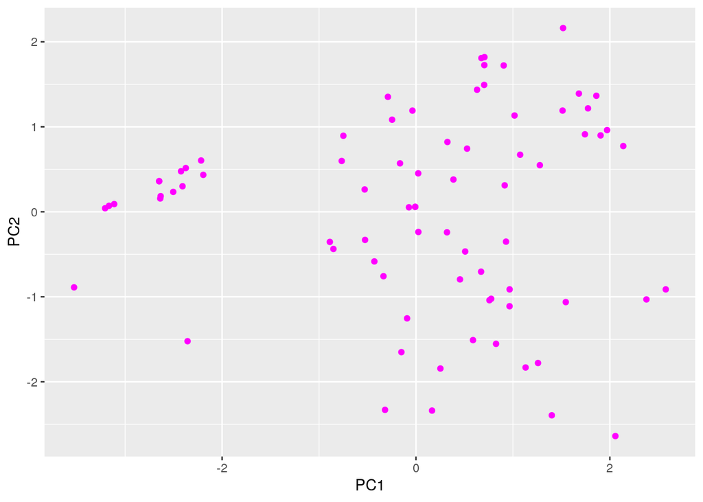

```r
starbucks_pcadf <- data.frame(starbucks_pca$scores)
pcaggplot <- data.frame(Name = starbucks_pcadf, PC1 = starbucks_pca$scores[,
    1], PC2 = starbucks_pca$scores[, 2])
pcaggplot %>% ggplot(aes(PC1, PC2)) + geom_point(color = "magenta")
```

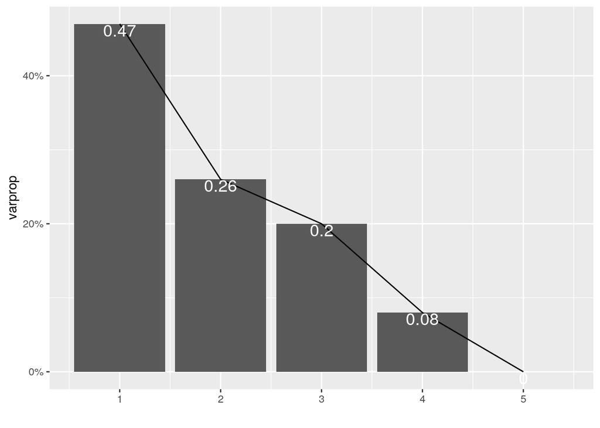

```r
eigval <- starbucks_pca$sdev^2
varprop = round(eigval/sum(eigval), 2)
ggplot() + geom_bar(aes(y = varprop, x = 1:5), stat = "identity") +
    xlab("") + geom_path(aes(y = varprop, x = 1:5)) + geom_text(aes(x = 1:5,
    y = varprop, label = round(varprop, 2)), vjust = 1, col = "white",
    size = 5) + scale_y_continuous(breaks = seq(0, 0.6, 0.2),
    labels = scales::percent) + scale_x_continuous(breaks = 1:10)
```

### Linear Classifier

```r
fit <- glm(highcals == "TRUE" ~ carb + fiber + protein, data = starbucks,
    family = "binomial")
score <- predict(fit, type = "response")
class_diag(score, starbucks$highcals, positive = "TRUE")
```

```
##            acc   sens   spec    ppv     f1     ba    auc
## Metrics 0.8312 0.9375 0.6552 0.8182 0.8738 0.7963 0.8211
```

```r
table(truth = factor(starbucks$highcals2 == 2, levels = c("TRUE",
    "FALSE")), prediction = factor(score > 0.5, levels = c("TRUE",
    "FALSE")))
```

```
##        prediction
## truth   TRUE FALSE
##   TRUE    45     3
##   FALSE   10    19
```

```r
k = 10
data <- sample_frac(starbucks)
folds <- rep(1:k, length.out = nrow(data))

diags <- NULL

i = 1
for (i in 1:k) {
    train <- data[folds != i, ]
    test <- data[folds == i, ]
    truth <- test$highcals
    fit <- glm(highcals == "TRUE" ~ carb + fiber + protein, data = starbucks,
        family = "binomial")
    probs <- predict(fit, newdata = test, type = "response")
    diags <- rbind(diags, class_diag(probs, truth, positive = "TRUE"))
}
summarize_all(diags, mean)
```

```
##       acc sens  spec     ppv      f1     ba  auc
## 1 0.83393 0.93 0.675 0.82917 0.87056 0.8025 0.83
```

We can see here that our model is doing better now that we have ran it with a k-fold CV. It is also not a superb score, but an improvement from 0.8211. It is not showing signs of overfitting because it is improving when we run it with a k-fold (which means that we are randomly splitting up the data into subsets, which shows us if our data is overfitting if the k-fold score is lower).

### Non-Parametric Classifier

```r
library(caret)
knn_fit <- knn3(highcals2 == "2" ~ carb + fiber + protein, data = starbucks)
prob_knn <- predict(knn_fit, newdata = starbucks)
class_diag(prob_knn[, 2], starbucks$highcals, positive = "TRUE")
```

```
##            acc   sens   spec    ppv     f1     ba    auc
## Metrics 0.9091 0.9792 0.7931 0.8868 0.9307 0.8861 0.9353
```

```r
table(truth = factor(starbucks$highcals2 == 2, levels = c("TRUE",
    "FALSE")), prediction = factor(prob_knn[, 1] > 0.5, levels = c("TRUE",
    "FALSE")))
```

```
##        prediction
## truth   TRUE FALSE
##   TRUE     0    48
##   FALSE   22     7
```

The model is demonstrated to be doing really well, with an AUC of 0.9353 can be translated to an A).

```r
k = 10
data <- sample_frac(starbucks)
folds <- rep(1:k, length.out = nrow(data))
diags <- NULL
i = 1
for (i in 1:k) {
    train <- data[folds != i, ]
    test <- data[folds == i, ]
    truth <- test$highcals
    fit <- knn3(highcals == "TRUE" ~ carb + fiber + protein,
        data = starbucks)
    probs <- predict(fit, newdata = test)[, 2]
    diags <- rbind(diags, class_diag(probs, truth, positive = "TRUE"))
}
summarize_all(diags, mean)
```

```
##       acc  sens    spec     ppv     f1      ba     auc
## 1 0.90892 0.975 0.85167 0.87071 0.9054 0.91333 0.97249
```

Again, this model shows that when ran with a k-fold CV, it does better than the previous AUC score. This means that there is no overfitting, as the value is higher when ran with a k-fold. This nonparametric model does better than the previous linear model, as the AUC scores are higher (in regards to its cross validation performance).

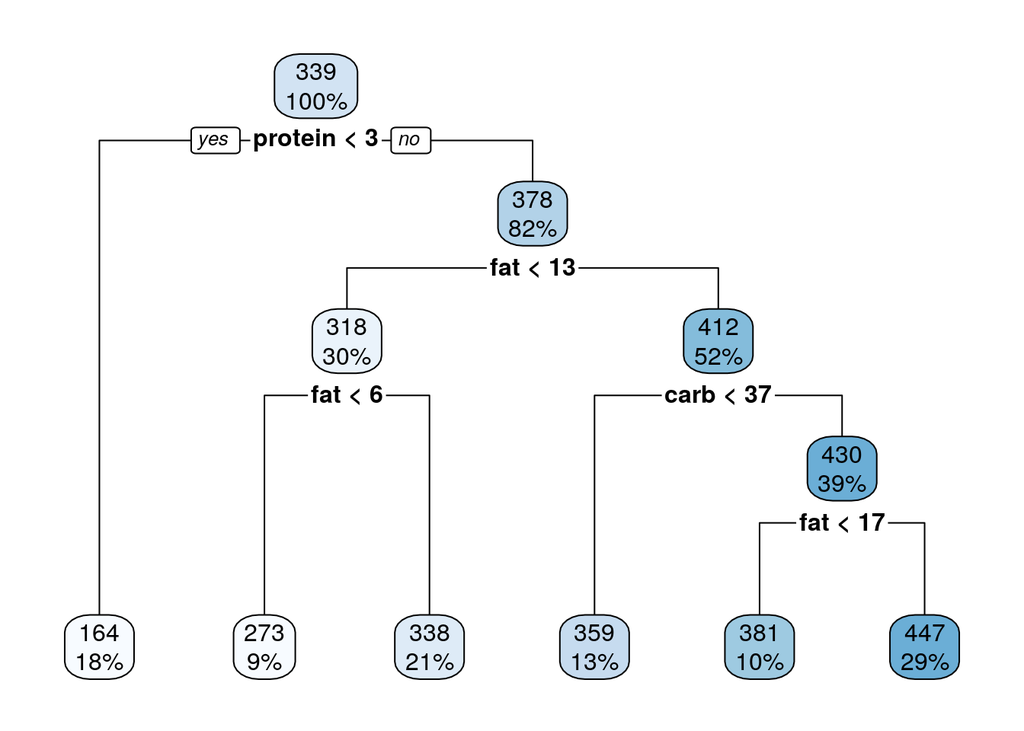

```r
library(rpart)
library(rpart.plot)
fit <- rpart(calories ~ fat + carb + fiber + protein + type,
    data = starbucks)
rpart.plot(fit)
```

### Regression/Numeric Prediction

```r
fit1 <- lm(calories ~ fat + carb + fiber + protein + type, data = starbucks)
yhat <- predict(fit1)
mean((starbucks$calories - yhat)^2)
```

```
## [1] 93.06924
```

```r
k = 5
data <- starbucks[sample(nrow(starbucks)), ]
folds <- cut(seq(1:nrow(starbucks)), breaks = k, labels = F)
diags <- NULL
for (i in 1:k) {
    train <- data[folds != i, ]
    test <- data[folds == i, ]
    fit <- lm(calories ~ fat + carb + fiber + protein + type,
        data = starbucks)
    yhat <- predict(fit, newdata = test)
    diags <- mean((starbucks$calories - yhat)^2)
}
mean(diags)
```

```
## [1] 22077.94
```

Here, I found the mean squared error (MSE), which was 93.06924. The smaller the number the better, so this number was not necessarily great. I then ran a k-fold CV on this same model, which had a value in the 20 thousands. The MSE was higher in CV, which is not good, as it shows that there is over fitting.

### Python

```r
library(reticulate)
```

```python
starbuckspy = r.starbucks
print(r.starbucks)
```

[output not shown]

```r
head(py$starbuckspy)
```

```
## $item
##  [1] "8-Grain Roll"
##  [2] "Apple Bran Muffin"
##  [3] "Apple Fritter"
##  [4] "Banana Nut Loaf"
##  [5] "Birthday Cake Mini Doughnut"
##  [6] "Blueberry Oat Bar"
##  [7] "Blueberry Scone"
##  [8] "Bountiful Blueberry Muffin"
##  [9] "Butter Croissant"
## [10] "Cheese Danish"
## [11] "Chocolate Chunk Cookie"
## [12] "Chocolate Cinnamon Bread"
## [13] "Chocolate Croissant"
## [14] "Chocolate Old-Fashioned Doughnut"
```

[output cut: 95 more lines]

To run the python code, we install the library reticulate. Then, we can name the dataset in python by putting “r.” in front of it, and by printing it we can see it and the structure it has in python. Then, to bring it back to R, we can use “py$” in front of the python dataset name.

### Concluding Remarks

This project taught me a lot about data manipulation! It is an extension of my first project, though using different data. Project 1 was a base level of the skills that we used, and project 2 really expanded on the aspect of data manipulation to gather information which was so cool!